# ADMT

Shahbaz Shaikh

2026-04-26

# Loan Default and Loss Prediction - Two Stage Modeling

## Loading Libraries

```r
library(data.table)
library(dplyr)
library(caret)
library(xgboost)
library(randomForest)
library(pROC)
library(Metrics)
library(ggplot2)
library(knitr)
library(glmnet)
library(pls)

set.seed(42)
options(scipen = 999)
```

## Loading Data

```r
train_path <- "data/train_v3.csv"
test_path  <- "data/test__no_lossv3.csv"

train_df <- fread(train_path)
test_df  <- fread(test_path)

cat("Train shape:", dim(train_df), "\n")
```

```
## Train shape: 80000 763
```

```r
cat("Test shape:", dim(test_df), "\n")
```

```
## Test shape: 25471 762
```

```r
head(train_df)
```

[output not shown]

[output cut: 657 more lines]

```r
head(test_df)
```

[output not shown]

[output cut: 649 more lines]

### Interpretation

The raw CSV files include one extra index-style column in addition to the modeling columns. In this R workflow it appears as `V1`. Since this column is not a real predictor, it should be removed before modeling so that the reported feature counts reflect only the usable input variables.

## Data Understanding and Initial Exploration

In this step, I inspect the dataset structure, missing values, and target distribution. This helps confirm that the project is a zero-inflated loss prediction problem, where most loans have no loss and only a smaller portion have positive loss.

```r
cat("Missing values in train (top 20):\n")
```

```
## Missing values in train (top 20):
```

```r
train_missing <- sort(colSums(is.na(train_df)), decreasing = TRUE)
head(train_missing, 20)
```

```
##  f662  f663  f159  f160  f169  f170  f618  f619  f330  f331  f179  f180  f422
## 14261 14261 14174 14174 14013 14013 13896 13896 13614 13614 12930 12930 10768
##  f653  f189  f190  f340  f341  f664  f665
## 10044  9276  9276  8997  8997  8561  8561
```

```r
cat("\nMissing values in test (top 20):\n")
```

```
##
## Missing values in test (top 20):
```

```r
test_missing <- sort(colSums(is.na(test_df)), decreasing = TRUE)
head(test_missing, 20)
```

```
## f662 f663 f159 f160 f618 f619 f330 f331 f169 f170 f179 f180 f422 f653 f189 f190
## 4572 4572 4562 4562 4511 4511 4453 4453 4404 4404 4232 4232 3467 3161 2958 2958
## f340 f341 f664 f665
## 2914 2914 2721 2721
```

```r
ggplot(data.frame(loss = train_df$loss), aes(x = loss)) +
  geom_histogram(bins = 50) +
  labs(
    title = "Training Loss Distribution",
    x = "loss",
    y = "count"
  )
```

[figure not shown]

```r
default_rate <- mean(train_df$loss > 0) * 100
cat(sprintf("Default rate: %.2f%%\n", default_rate))
```

```
## Default rate: 9.22%
```

### Interpretation

The target variable is highly imbalanced and zero-inflated. This makes a two-stage modeling approach appropriate. In Stage 1, the model predicts whether a loan will incur any loss. In Stage 2, the model predicts the severity of loss only for loans that actually default.

## Feature and Target Separation

In this step, I separate the identifiers, the continuous target (`loss`), the binary target (`default`), and the feature matrix. The test set keeps the `id` column separately so it can be used later when generating the final submission file.

```r
# Remove extra CSV index column if present
index_like_cols <- c("Unnamed: 0", "V1", "X")
train_index_cols <- intersect(names(train_df), index_like_cols)
test_index_cols  <- intersect(names(test_df), index_like_cols)

if (length(train_index_cols) > 0) {
  train_df <- train_df %>% select(-all_of(train_index_cols))
}

if (length(test_index_cols) > 0) {
  test_df <- test_df %>% select(-all_of(test_index_cols))
}

train_ids <- train_df$id
test_ids  <- test_df$id

y_loss <- train_df$loss
y_default <- ifelse(y_loss > 0, 1, 0)

X_train_raw <- train_df %>% select(-id, -loss) %>% as.data.frame()
X_test_raw  <- test_df %>% select(-id) %>% as.data.frame()

X_test_raw <- X_test_raw[, names(X_train_raw)]

data_overview <- data.frame(
  Metric = c(
    "Training Rows",
    "Test Rows",
    "Training Columns After Cleanup",
    "Test Columns After Cleanup",
    "Number of Raw Predictor Features",
    "Default Rate",
    "Zero Loss Rate"
  ),
  Value = c(
    nrow(X_train_raw),
    nrow(X_test_raw),
    ncol(train_df),
    ncol(test_df),
    ncol(X_train_raw),
    paste0(round(mean(y_default) * 100, 2), "%"),
    paste0(round(mean(y_loss == 0) * 100, 2), "%")
  )
)

kable(data_overview, caption = "Dataset Overview")
```

Dataset Overview

| Metric | Value |
| --- | --- |
| Training Rows | 80000 |
| Test Rows | 25471 |
| Training Columns After Cleanup | 762 |
| Test Columns After Cleanup | 761 |
| Number of Raw Predictor Features | 760 |
| Default Rate | 9.22% |
| Zero Loss Rate | 90.78% |

### Interpretation

After removing the extra index column and separating out `id` and `loss`, the modeling dataset contains 760 predictor features in both train and test. This is the actual set of usable modeling inputs for the rest of the analysis.

## Train-Validation Split

The raw training data is split into training and validation subsets using an 80/20 ratio. Stratification is based on the binary default variable so that the class imbalance is preserved in both sets.

```r
split_index <- createDataPartition(y_default, p = 0.8, list = FALSE)

X_train_split_raw <- X_train_raw[split_index, , drop = FALSE]
X_val_split_raw   <- X_train_raw[-split_index, , drop = FALSE]

y_loss_train <- y_loss[split_index]
y_loss_val   <- y_loss[-split_index]

y_default_train <- y_default[split_index]
y_default_val   <- y_default[-split_index]
```

## Encoding Non-Numeric Features

Non-numeric columns must be converted into numeric form before modeling. For this dataset, an integer-mapping approach is computationally lighter than full one-hot encoding, especially with many variables. The mapping is fit on the training split only and then applied to validation and test data. Unseen categories are assigned `0`, which prevents leakage and keeps the pipeline manageable.

```r
fit_level_maps <- function(df) {
  level_maps <- list()
  for (col in names(df)) {
    if (!is.numeric(df[[col]])) {
      level_maps[[col]] <- unique(as.character(df[[col]]))
    }
  }
  level_maps
}

apply_level_maps <- function(df, level_maps) {
  df_out <- df
  for (col in names(df_out)) {
    if (col %in% names(level_maps)) {
      mapped <- match(as.character(df_out[[col]]), level_maps[[col]])
      mapped[is.na(mapped)] <- 0L
      df_out[[col]] <- mapped
    }
  }
  df_out[] <- lapply(df_out, function(x) {
    if (is.logical(x)) as.integer(x) else x
  })
  as.data.frame(df_out)
}

split_level_maps <- fit_level_maps(X_train_split_raw)

X_train_encoded <- apply_level_maps(X_train_split_raw, split_level_maps)
X_val_encoded   <- apply_level_maps(X_val_split_raw, split_level_maps)
X_test_encoded  <- apply_level_maps(X_test_raw, split_level_maps)

safe_feature_names <- make.names(names(X_train_encoded), unique = TRUE)
names(X_train_encoded) <- safe_feature_names
names(X_val_encoded)   <- safe_feature_names
names(X_test_encoded)  <- safe_feature_names

cat("Encoded train shape:", dim(X_train_encoded), "\n")
```

```
## Encoded train shape: 64000 760
```

```r
cat("Encoded validation shape:", dim(X_val_encoded), "\n")
```

```
## Encoded validation shape: 16000 760
```

```r
cat("Encoded test shape:", dim(X_test_encoded), "\n")
```

```
## Encoded test shape: 25471 760
```

### Interpretation

This encoding approach keeps the preprocessing lightweight while ensuring that the mapping is learned from training data only instead of from combined train and test data.

## Handling Missing Values

Median imputation is used because it is robust to outliers and works well for financial data. The imputer is fit only on the training split and then applied to validation and test data.

```r
imputer <- preProcess(X_train_encoded, method = "medianImpute")

X_train_imputed <- predict(imputer, X_train_encoded)
X_val_imputed   <- predict(imputer, X_val_encoded)
X_test_imputed  <- predict(imputer, X_test_encoded)
```

## Feature Scaling

Standardization is applied to make the numeric features comparable in scale. This is especially important for linear and regularized models such as Logistic Regression, Elastic Net, Ridge, and PLS.

```r
scaler <- preProcess(X_train_imputed, method = c("center", "scale"))
X_train_scaled <- predict(scaler, X_train_imputed)
X_val_scaled   <- predict(scaler, X_val_imputed)
X_test_scaled  <- predict(scaler, X_test_imputed)

clean_numeric_df <- function(df) {
  df[] <- lapply(df, function(x) {
    x <- as.numeric(x)
    x[!is.finite(x)] <- 0
    x
  })
  as.data.frame(df)
}

X_train_scaled <- clean_numeric_df(X_train_scaled)
X_val_scaled   <- clean_numeric_df(X_val_scaled)
X_test_scaled  <- clean_numeric_df(X_test_scaled)
```

## Feature Reduction using PCA and PLS

This section explores whether dimensionality reduction can simplify the feature space while still preserving predictive information. PCA and PLS are compared to see how well reduced representations support loss prediction on the validation set.

### Why this section matters

This part is exploratory rather than final-model selection. The goal is to check whether reducing the feature space helps simplify the problem without losing too much predictive information. PCA summarizes variance in the predictors, while PLS tries to find components that are more directly related to the target.

### Step 1: Prepare PCA inputs and select the number of components

In this chunk, I remove constant columns, fit PCA on the training data only, and keep enough components to explain 95% of the variance.

```r
# PCA retaining 95% of variance
non_constant_cols <- apply(X_train_scaled, 2, function(x) is.finite(sd(x)) && sd(x) > 0)

X_train_pca_input <- X_train_scaled[, non_constant_cols, drop = FALSE]
X_val_pca_input   <- X_val_scaled[, non_constant_cols, drop = FALSE]

pca_full <- prcomp(X_train_pca_input, center = FALSE, scale. = FALSE)
variance_ratio <- (pca_full$sdev ^ 2) / sum(pca_full$sdev ^ 2)
variance_ratio[!is.finite(variance_ratio)] <- 0
cumulative_variance <- cumsum(variance_ratio)

pca_components <- which(cumulative_variance >= 0.95)[1]
if (is.na(pca_components) || length(pca_components) == 0) {
  pca_components <- ncol(X_train_pca_input)
}

X_train_pca <- predict(pca_full, X_train_pca_input)[, 1:pca_components, drop = FALSE]
X_val_pca   <- predict(pca_full, X_val_pca_input)[, 1:pca_components, drop = FALSE]

cat("Optimal PCA Components (95% variance):", pca_components, "\n")
```

```
## Optimal PCA Components (95% variance): 1
```

```r
# PLS comparison using a small search over component counts
pls_range <- c(5, 10, 15, 20, 25)
pls_range <- pls_range[pls_range < nrow(X_train_scaled)]
pls_range <- pls_range[pls_range <= ncol(X_train_scaled)]

best_pls_components <- NA
best_pls_mae <- Inf

for (n_comp in pls_range) {
  pls_fit_tmp <- plsr(
    y_loss_train ~ .,
    data = data.frame(y_loss_train = y_loss_train, X_train_scaled),
    ncomp = n_comp,
    method = "oscorespls",
    validation = "none"
  )

  pred_tmp <- as.vector(
    predict(pls_fit_tmp, newdata = data.frame(X_val_scaled), ncomp = n_comp)
  )
  pred_tmp[!is.finite(pred_tmp)] <- 0
  mae_tmp <- mae(y_loss_val, pred_tmp)
  if (!is.finite(mae_tmp)) {
    mae_tmp <- Inf
  }

  cat("PLS Components:", n_comp, "MAE:", round(mae_tmp, 6), "\n")

  if (mae_tmp < best_pls_mae) {
    best_pls_mae <- mae_tmp
    best_pls_components <- n_comp
  }
}
```

```
## PLS Components: 5 MAE: 1.411399
## PLS Components: 10 MAE: 1.411193
## PLS Components: 15 MAE: 1.411112
## PLS Components: 20 MAE: 1.410756
## PLS Components: 25 MAE: 1.411027
```

```r
cat("\nBest PLS Components:", best_pls_components, "\n")
```

```
##
## Best PLS Components: 20
```

```r
cat("Best PLS MAE:", round(best_pls_mae, 6), "\n")
```

```
## Best PLS MAE: 1.410756
```

### Step 2: Compare PCA and PLS using validation MAE

After identifying the PCA and PLS representations, I compare them using a common validation metric. Lower MAE means the transformed feature space is more useful for predicting loss values.

```r
# PCA-based linear regression
pca_train_df <- data.frame(y_loss_train = y_loss_train, X_train_pca)
pca_val_df   <- data.frame(X_val_pca)

model_pca <- lm(y_loss_train ~ ., data = pca_train_df)
pred_pca <- predict(model_pca, newdata = pca_val_df)
pred_pca[!is.finite(pred_pca)] <- 0
mae_pca <- mae(y_loss_val, pred_pca)

# Final PLS model based on selected component count
pls_fit <- plsr(
  y_loss_train ~ .,
  data = data.frame(y_loss_train = y_loss_train, X_train_scaled),
  ncomp = best_pls_components,
  method = "oscorespls",
  validation = "none"
)

pred_pls <- as.vector(
  predict(pls_fit, newdata = data.frame(X_val_scaled), ncomp = best_pls_components)
)
pred_pls[!is.finite(pred_pls)] <- 0
mae_pls <- mae(y_loss_val, pred_pls)

dim_reduction_results <- data.frame(
  Method = c("PCA", "PLS"),
  MAE = c(mae_pca, mae_pls)
)

kable(dim_reduction_results, caption = "PCA vs PLS Comparison (MAE)")
```

PCA vs PLS Comparison (MAE)

| Method | MAE |
| --- | --- |
| PCA | 1.411261 |
| PLS | 1.410756 |

## Stage 1: Default Classification Models

The first stage predicts the probability that a loan incurs any loss.

### Why Stage 1 comes first

Because most loans have zero loss, it is more natural to first predict whether a loan defaults at all. This turns the first stage into a classification problem, and the output probability can later be combined with predicted severity from Stage 2.

### Logistic Regression Baseline

This baseline gives a simple, regularized model that is easy to interpret and useful for comparison against more flexible methods.

```r
logistic_model <- cv.glmnet(
  x = as.matrix(X_train_scaled),
  y = y_default_train,
  family = "binomial",
  alpha = 0,
  type.measure = "auc",
  nfolds = 5
)

logistic_val_proba <- as.vector(
  predict(logistic_model, newx = as.matrix(X_val_scaled), s = "lambda.min", type = "response")
)
logistic_auc <- as.numeric(roc(y_default_val, logistic_val_proba, quiet = TRUE)$auc)

cat("Logistic Regression Validation AUC:", round(logistic_auc, 6), "\n")
```

```
## Logistic Regression Validation AUC: 0.702779
```

### Elastic Net Logistic Regression

Elastic Net extends the baseline by blending ridge and lasso style regularization. This can help when the dataset is high-dimensional and features may be correlated.

```r
x_train_mat <- as.matrix(X_train_scaled)
x_val_mat   <- as.matrix(X_val_scaled)

alpha_grid <- c(0.1, 0.5, 0.9)
lambda_grid <- 10 ^ seq(-3, 1, length.out = 20)

best_enet_auc <- -Inf
best_alpha <- NA
best_lambda <- NA
best_enet_model <- NULL

for (alpha_value in alpha_grid) {
  cv_fit <- cv.glmnet(
    x = x_train_mat,
    y = y_default_train,
    family = "binomial",
    alpha = alpha_value,
    lambda = lambda_grid,
    type.measure = "auc",
    nfolds = 5
  )

  val_proba_tmp <- as.vector(predict(cv_fit, newx = x_val_mat, s = "lambda.min", type = "response"))
  auc_tmp <- as.numeric(roc(y_default_val, val_proba_tmp, quiet = TRUE)$auc)

  if (auc_tmp > best_enet_auc) {
    best_enet_auc <- auc_tmp
    best_alpha <- alpha_value
    best_lambda <- cv_fit$lambda.min
    best_enet_model <- cv_fit
  }
}

elastic_net_val_proba <- as.vector(predict(best_enet_model, newx = x_val_mat, s = "lambda.min", type = "response"))
elastic_net_auc <- as.numeric(roc(y_default_val, elastic_net_val_proba, quiet = TRUE)$auc)

cat("Best Elastic Net alpha:", best_alpha, "\n")
```

```
## Best Elastic Net alpha: 0.5
```

```r
cat("Best Elastic Net lambda:", best_lambda, "\n")
```

```
## Best Elastic Net lambda: 0.001
```

```r
cat("Elastic Net Validation AUC:", round(elastic_net_auc, 6), "\n")
```

```
## Elastic Net Validation AUC: 0.705165
```

### XGBoost Classifier

This model is the main nonlinear classifier in the report. XGBoost is appropriate here because it can capture interactions and nonlinear default patterns more effectively than a purely linear model.

```r
scale_pos_weight <- sum(y_default_train == 0) / max(sum(y_default_train == 1), 1)

dtrain_cls <- xgb.DMatrix(data = as.matrix(X_train_scaled), label = y_default_train)
dval_cls   <- xgb.DMatrix(data = as.matrix(X_val_scaled), label = y_default_val)

xgb_classifier <- xgb.train(
  params = list(
    objective = "binary:logistic",
    eval_metric = "auc",
    max_depth = 4,
    eta = 0.05,
    subsample = 0.9,
    colsample_bytree = 0.9,
    scale_pos_weight = scale_pos_weight
  ),
  data = dtrain_cls,
  nrounds = 300,
  verbose = 0
)

xgb_classifier_val_proba <- predict(xgb_classifier, dval_cls)
xgb_classifier_auc <- as.numeric(roc(y_default_val, xgb_classifier_val_proba, quiet = TRUE)$auc)

cat("XGBoost Validation AUC:", round(xgb_classifier_auc, 6), "\n")
```

```
## XGBoost Validation AUC: 0.712861
```

### Stage 1 Model Comparison

This comparison table and chart make it easier to see which classification model performs best on the validation set.

```r
classification_results <- data.frame(
  Model = c("Logistic Regression", "Elastic Net Logistic", "XGBoost Classifier"),
  AUC = c(logistic_auc, elastic_net_auc, xgb_classifier_auc)
) %>%
  arrange(desc(AUC))

kable(classification_results, caption = "Stage 1 Classification Results")
```

Stage 1 Classification Results

| Model | AUC |
| --- | --- |
| XGBoost Classifier | 0.7128609 |
| Elastic Net Logistic | 0.7051647 |
| Logistic Regression | 0.7027792 |

```r
ggplot(classification_results, aes(x = reorder(Model, AUC), y = AUC)) +
  geom_col(fill = "steelblue") +
  coord_flip() +
  labs(
    title = "Stage 1 Default Classification Model Comparison",
    x = "Model",
    y = "AUC"
  )
```

[figure not shown]

## Stage 1 Improvements

This section adds a second pass of Stage 1 checks, including cross-validated logistic regression, a random forest benchmark, and a stronger comparison against XGBoost.

### Cross-Validated Logistic Regression

This chunk uses cross-validation to evaluate the logistic baseline more robustly.

```r
cv_control <- trainControl(
  method = "cv",
  number = 5,
  classProbs = TRUE,
  summaryFunction = twoClassSummary
)

cv_train_df <- data.frame(
  Default = factor(ifelse(y_default_train == 1, "Default", "NoDefault"),
                   levels = c("NoDefault", "Default")),
  X_train_scaled
)

logistic_cv_model <- train(
  Default ~ .,
  data = cv_train_df,
  method = "glm",
  family = binomial(),
  metric = "ROC",
  trControl = cv_control
)
print(logistic_cv_model)
```

```
## Generalized Linear Model
##
## 64000 samples
##   760 predictor
##     2 classes: 'NoDefault', 'Default'
##
## No pre-processing
## Resampling: Cross-Validated (5 fold)
## Summary of sample sizes: 51200, 51200, 51200, 51200, 51200
## Resampling results:
##
##   ROC        Sens       Spec
##   0.4839103  0.4803019  0.4875188
```

### Random Forest Benchmark

Random Forest gives a second tree-based benchmark. It helps show whether the advantage of XGBoost comes specifically from boosting rather than from tree models in general.

```r
rf_classifier <- randomForest(
  x = X_train_scaled,
  y = factor(y_default_train, levels = c(0, 1), labels = c("NoDefault", "Default")),
  ntree = 300
)

rf_val_proba <- predict(rf_classifier, X_val_scaled, type = "prob")[, "Default"]
rf_auc <- as.numeric(roc(y_default_val, rf_val_proba, quiet = TRUE)$auc)

cat("Random Forest Validation AUC:", round(rf_auc, 6), "\n")
```

```
## Random Forest Validation AUC: 0.621714
```

### ROC Curve Comparison

The ROC curves show how each classifier behaves across all classification thresholds, not just one cutoff. This is useful because the final project cares about ranking risky loans well.

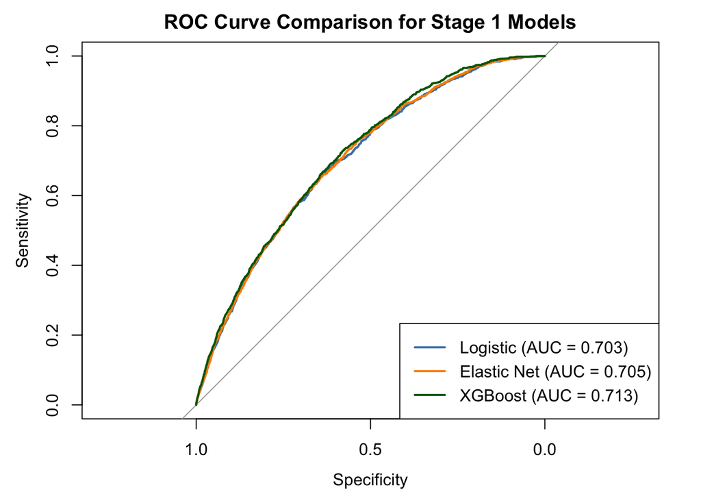

```r
roc_log <- roc(y_default_val, logistic_val_proba, quiet = TRUE)
roc_enet <- roc(y_default_val, elastic_net_val_proba, quiet = TRUE)
roc_xgb <- roc(y_default_val, xgb_classifier_val_proba, quiet = TRUE)

plot(roc_log, col = "steelblue", main = "ROC Curve Comparison for Stage 1 Models")
plot(roc_enet, col = "darkorange", add = TRUE)
plot(roc_xgb, col = "darkgreen", add = TRUE)
legend(
  "bottomright",
  legend = c(
    paste0("Logistic (AUC = ", round(as.numeric(roc_log$auc), 3), ")"),
    paste0("Elastic Net (AUC = ", round(as.numeric(roc_enet$auc), 3), ")"),
    paste0("XGBoost (AUC = ", round(as.numeric(roc_xgb$auc), 3), ")")
  ),
  col = c("steelblue", "darkorange", "darkgreen"),
  lwd = 2
)
```

## Stage 2: Prepare Loss-Only Data

For severity modeling, I keep only the observations with positive loss. This follows the logic of a two-stage expected-loss framework, where Stage 1 handles default occurrence and Stage 2 handles loss magnitude among defaults.

### Why zero-loss rows are removed here

Once Stage 1 handles the default decision, Stage 2 should focus only on the size of loss among defaulted loans. Including all zero-loss rows again would blur the severity problem and make the regression target much less informative.

```r
default_train_mask <- y_loss_train > 0
default_val_mask   <- y_loss_val > 0

X_train_loss_only <- X_train_scaled[default_train_mask, , drop = FALSE]
X_val_loss_only   <- X_val_scaled[default_val_mask, , drop = FALSE]

y_train_loss_only <- y_loss_train[default_train_mask]
y_val_loss_only   <- y_loss_val[default_val_mask]

cat("Stage 2 training rows:", nrow(X_train_loss_only), "\n")
```

```
## Stage 2 training rows: 5926
```

```r
cat("Stage 2 validation rows:", nrow(X_val_loss_only), "\n")
```

```
## Stage 2 validation rows: 1453
```

## Stage 2: Loss Severity Models

This section compares Ridge, PLS, and XGBoost for Stage 2. The final prediction pipeline is kept consistent with the strongest Stage 2 model selected from this comparison.

### What this stage is trying to learn

At this point, the task is no longer “will there be a loss?” but instead “how large will the loss be if default happens?” That is why the models are evaluated with MAE rather than AUC.

### Ridge Regression

Ridge regression provides a linear baseline for severity prediction.

```r
ridge_cv <- cv.glmnet(
  x = as.matrix(X_train_loss_only),
  y = y_train_loss_only,
  alpha = 0,
  family = "gaussian",
  nfolds = 5
)

ridge_val_pred <- as.vector(predict(ridge_cv, newx = as.matrix(X_val_loss_only), s = "lambda.min"))
ridge_mae <- mae(y_val_loss_only, ridge_val_pred)

cat("Ridge Regression MAE:", round(ridge_mae, 6), "\n")
```

```
## Ridge Regression MAE: 5.934699
```

### PLS Regression

PLS is useful when there are many predictors and we want a lower-dimensional representation that still stays connected to the response variable.

```r
pls_components_stage2 <- min(10, ncol(X_train_loss_only), nrow(X_train_loss_only) - 1)
pls_components_stage2 <- max(pls_components_stage2, 1)

pls_stage2 <- plsr(
  y_train_loss_only ~ .,
  data = data.frame(y_train_loss_only = y_train_loss_only, X_train_loss_only),
  ncomp = pls_components_stage2,
  method = "oscorespls",
  validation = "none"
)

pls_val_pred <- as.vector(predict(pls_stage2, newdata = data.frame(X_val_loss_only), ncomp = pls_components_stage2))
pls_mae_stage2 <- mae(y_val_loss_only, pls_val_pred)

cat("PLS Regression MAE:", round(pls_mae_stage2, 6), "\n")
```

```
## PLS Regression MAE: 6.432512
```

### XGBoost Regressor

This is the main nonlinear Stage 2 model. It is especially suitable when severity depends on feature interactions and nonlinear structure.

```r
dtrain_reg <- xgb.DMatrix(data = as.matrix(X_train_loss_only), label = y_train_loss_only)
dval_reg   <- xgb.DMatrix(data = as.matrix(X_val_loss_only), label = y_val_loss_only)

xgb_regressor <- xgb.train(
  params = list(
    objective = "reg:squarederror",
    eval_metric = "mae",
    max_depth = 4,
    eta = 0.05,
    subsample = 0.9,
    colsample_bytree = 0.9
  ),
  data = dtrain_reg,
  nrounds = 400,
  verbose = 0
)

xgb_regressor_val_pred <- predict(xgb_regressor, dval_reg)
xgb_regressor_mae <- mae(y_val_loss_only, xgb_regressor_val_pred)

cat("XGBoost Regressor MAE:", round(xgb_regressor_mae, 6), "\n")
```

```
## XGBoost Regressor MAE: 5.033003
```

### Stage 2 Model Comparison

This section summarizes the severity models and shows which one gives the lowest validation error.

```r
regression_results <- data.frame(
  Model = c("Ridge Regression", "PLS Regression", "XGBoost Regressor"),
  MAE = c(ridge_mae, pls_mae_stage2, xgb_regressor_mae)
) %>%
  arrange(MAE)

kable(regression_results, caption = "Stage 2 Regression Results")
```

Stage 2 Regression Results

| Model | MAE |
| --- | --- |
| XGBoost Regressor | 5.033003 |
| Ridge Regression | 5.934699 |
| PLS Regression | 6.432512 |

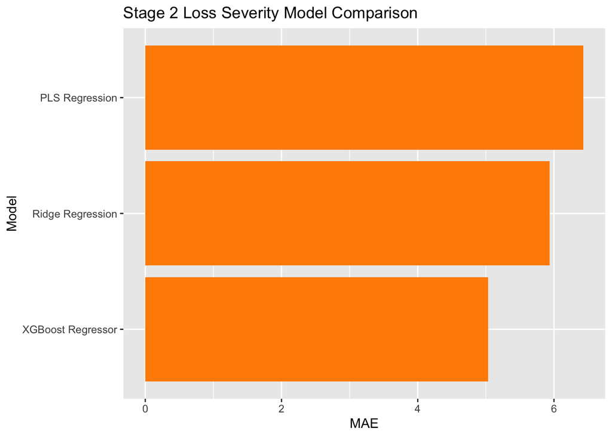

```r
ggplot(regression_results, aes(x = reorder(Model, MAE), y = MAE)) +
  geom_col(fill = "darkorange") +
  coord_flip() +
  labs(
    title = "Stage 2 Loss Severity Model Comparison",
    x = "Model",
    y = "MAE"
  )
```

### Actual vs Predicted Loss Severity

This diagnostic plot helps check whether the best regression model is following the general pattern of the true loss values.

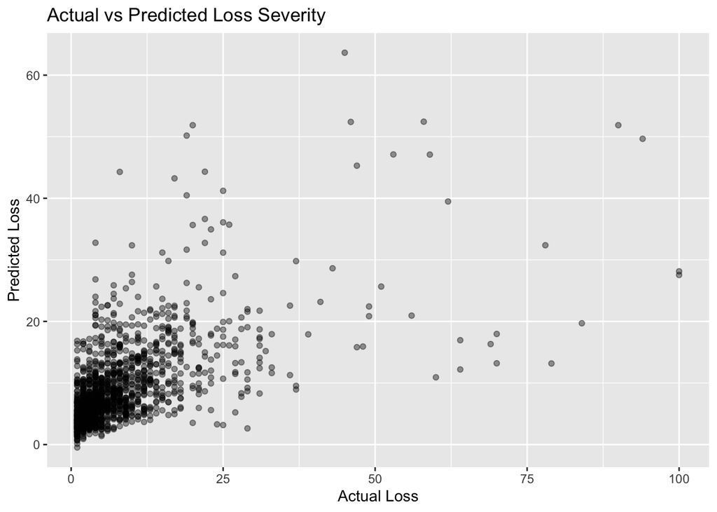

```r
actual_vs_predicted <- data.frame(
  Actual_Loss = y_val_loss_only,
  Predicted_Loss = xgb_regressor_val_pred
)

ggplot(actual_vs_predicted, aes(x = Actual_Loss, y = Predicted_Loss)) +
  geom_point(alpha = 0.4) +
  labs(
    title = "Actual vs Predicted Loss Severity",
    x = "Actual Loss",
    y = "Predicted Loss"
  )
```

## Train Final Models on Full Training Data and Predict Test Loss

This section builds the final submission pipeline using the full training data. Since XGBoost Regressor is evaluated as the strongest Stage 2 model, it is also used in the final prediction pipeline.

### Step 1: Rebuild the full encoded dataset

Before making final predictions, I refit the preprocessing steps on the complete training data so the final models can learn from all available labeled observations.

```r
# Re-encode full training and test data using maps learned from the full training set
full_level_maps <- fit_level_maps(X_train_raw)
X_full_train_encoded <- apply_level_maps(X_train_raw, full_level_maps)
X_full_test_encoded  <- apply_level_maps(X_test_raw, full_level_maps)

full_safe_feature_names <- make.names(names(X_full_train_encoded), unique = TRUE)
names(X_full_train_encoded) <- full_safe_feature_names
names(X_full_test_encoded)  <- full_safe_feature_names

# Refit preprocessing on full training data
full_imputer <- preProcess(X_full_train_encoded, method = "medianImpute")
X_full_train_imputed <- predict(full_imputer, X_full_train_encoded)
X_full_test_imputed  <- predict(full_imputer, X_full_test_encoded)

full_scaler <- preProcess(X_full_train_imputed, method = c("center", "scale"))
X_full_train_scaled <- predict(full_scaler, X_full_train_imputed)
X_full_test_scaled  <- predict(full_scaler, X_full_test_imputed)

X_full_train_scaled <- clean_numeric_df(X_full_train_scaled)
X_full_test_scaled  <- clean_numeric_df(X_full_test_scaled)
```

### Step 2: Train the final Stage 1 classifier

This chunk fits the XGBoost classifier on the full training set so it can produce final default probabilities for the test set.

```r
# Final Stage 1 classifier
full_scale_pos_weight <- sum(y_default == 0) / max(sum(y_default == 1), 1)

dtrain_full_cls <- xgb.DMatrix(data = as.matrix(X_full_train_scaled), label = y_default)
dtest_full <- xgb.DMatrix(data = as.matrix(X_full_test_scaled))

final_xgb_classifier <- xgb.train(
  params = list(
    objective = "binary:logistic",
    eval_metric = "auc",
    max_depth = 4,
    eta = 0.05,
    subsample = 0.9,
    colsample_bytree = 0.9,
    scale_pos_weight = full_scale_pos_weight
  ),
  data = dtrain_full_cls,
  nrounds = 300,
  verbose = 0
)
```

### Step 3: Train the final Stage 2 regressor

This chunk fits the final severity model using only positive-loss rows from the full training data.

```r
# Final Stage 2 regressor using only positive-loss rows
full_default_mask <- y_loss > 0
X_full_train_loss_only <- X_full_train_scaled[full_default_mask, , drop = FALSE]
y_full_loss_only <- y_loss[full_default_mask]

dtrain_full_reg <- xgb.DMatrix(data = as.matrix(X_full_train_loss_only), label = y_full_loss_only)

final_xgb_regressor <- xgb.train(
  params = list(
    objective = "reg:squarederror",
    eval_metric = "mae",
    max_depth = 4,
    eta = 0.05,
    subsample = 0.9,
    colsample_bytree = 0.9
  ),
  data = dtrain_full_reg,
  nrounds = 400,
  verbose = 0
)
```

### Step 4: Generate final expected-loss predictions

The final prediction is the expected loss for each test record. It is computed by multiplying the probability of default from Stage 1 by the predicted severity from Stage 2.

```r
# Test predictions
test_default_probability <- predict(final_xgb_classifier, dtest_full)
test_loss_prediction <- predict(final_xgb_regressor, dtest_full)
test_loss_prediction <- pmax(test_loss_prediction, 0)

final_test_prediction <- test_default_probability * test_loss_prediction

submission_df <- data.frame(
  id = test_ids,
  loss = final_test_prediction
)

write.csv(submission_df, "submission.csv", row.names = FALSE)

head(submission_df, 20)
```

```
##        id      loss
## 1    7933 10.618965
## 2  101860  7.551583
## 3   62580  1.793808
## 4    1760  5.205888
## 5   48008  5.190197
## 6    9308  4.200051
## 7   27862  4.801249
## 8   87760  5.061059
## 9   53334  1.121561
## 10  72303  5.529714
## 11  63146  5.233066
## 12  36604  3.103809
## 13  39206  5.991343
## 14  50474  3.348645
## 15   1660  3.884473
## 16  67950  6.738070
## 17  74349  5.634570
## 18  96978  7.325283
## 19 103963  2.084774
## 20  22864  2.948133
```

## Final Test Summary

This section gives a simple business-style summary of the test predictions, including how many loans would be flagged as defaults using a fixed threshold and how many defaults are expected on average from the probability outputs.

```r
default_threshold <- 0.5
predicted_default_count <- sum(test_default_probability >= default_threshold)
predicted_default_pct <- predicted_default_count / length(test_default_probability) * 100
expected_default_count <- sum(test_default_probability)
expected_default_pct <- mean(test_default_probability) * 100
total_test_obs <- length(test_default_probability)

test_default_summary <- data.frame(
  Metric = c(
    "Total Test Observations",
    "Predicted Defaults (threshold=0.5)",
    "Predicted Default Percentage",
    "Expected Defaults (sum of probabilities)",
    "Expected Default Percentage"
  ),
  Value = c(
    total_test_obs,
    predicted_default_count,
    paste0(round(predicted_default_pct, 2), "%"),
    round(expected_default_count, 2),
    paste0(round(expected_default_pct, 2), "%")
  )
)

kable(test_default_summary, caption = "Final Test Default Summary")
```

Final Test Default Summary

| Metric | Value |
| --- | --- |
| Total Test Observations | 25471 |
| Predicted Defaults (threshold=0.5) | 11236 |
| Predicted Default Percentage | 44.11% |
| Expected Defaults (sum of probabilities) | 11359.37 |
| Expected Default Percentage | 44.6% |

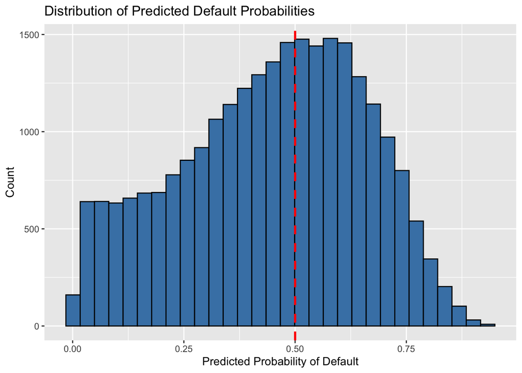

```r
ggplot(data.frame(probability = test_default_probability), aes(x = probability)) +
  geom_histogram(bins = 30, fill = "steelblue", color = "black") +
  geom_vline(xintercept = default_threshold, color = "red", linetype = "dashed", linewidth = 1) +
  labs(
    title = "Distribution of Predicted Default Probabilities",
    x = "Predicted Probability of Default",
    y = "Count"
  )
```

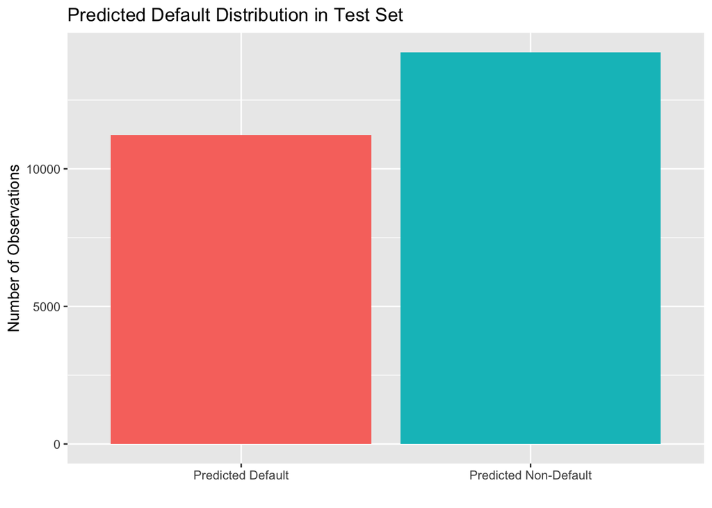

```r
predicted_default_distribution <- data.frame(
  Category = c("Predicted Non-Default", "Predicted Default"),
  Count = c(total_test_obs - predicted_default_count, predicted_default_count)
)

ggplot(predicted_default_distribution, aes(x = Category, y = Count, fill = Category)) +
  geom_col(show.legend = FALSE) +
  labs(
    title = "Predicted Default Distribution in Test Set",
    x = "",
    y = "Number of Observations"
  )
```

## Final Summary

This final chunk prints the most important project metrics in one place so the results are easy to review.

```r
cat("\n========== FINAL MODEL SUMMARY ==========\n")
```

```
##
## ========== FINAL MODEL SUMMARY ==========
```

```r
cat("Dataset Size:", nrow(X_full_train_encoded), "training rows\n")
```

```
## Dataset Size: 80000 training rows
```

```r
cat("Encoded Features:", ncol(X_full_train_encoded), "\n")
```

```
## Encoded Features: 760
```

```r
cat("Default Rate:", round(mean(y_default) * 100, 2), "%\n")
```

```
## Default Rate: 9.22 %
```

```r
cat("Best Stage 1 Model Used for Final Submission: XGBoost\n")
```

```
## Best Stage 1 Model Used for Final Submission: XGBoost
```

```r
cat("Validation AUC:", round(xgb_classifier_auc, 4), "\n")
```

```
## Validation AUC: 0.7129
```

```r
cat("Best Stage 2 Model Used for Final Submission: XGBoost Regressor\n")
```

```
## Best Stage 2 Model Used for Final Submission: XGBoost Regressor
```

```r
cat("Validation MAE:", round(xgb_regressor_mae, 4), "\n")
```

```
## Validation MAE: 5.033
```

## Conclusion

This R Markdown begins with data inspection, builds a two-stage modeling framework, compares multiple models at each stage, and finishes by generating a submission file in the required `id, loss` format.

The final pipeline predicts expected loss as:

$$\text{Expected Loss} = P(\text{Default}) \times \text{Predicted Loss
Severity}$$